Replication output for article, “hermiter: R package for Sequential Nonparametric Estimation”. The output below corresponds to the output produced by running knitr::spin() on the article_replication.R script, with short_run set to TRUE.

Load libraries.

```r
options(dplyr.summarise.inform = F)
if(!require(benchden)) devtools::install_github("thmild/benchden")
library(hermiter)
library(tdigest)
library(microbenchmark)
library(dplyr)
library(randtoolbox)
library(ggplot2)
library(patchwork)
library(arrow)
library(colorspace)
```

Choose whether to run quick version of reproduction script i.e. under an hour of processing time on hardware specified in manuscript versus full version which would take several hours of run-time.

```r
short_run <- TRUE
if (short_run == TRUE){
  total_number_of_runs <- 10
} else {
  total_number_of_runs <- 100
}
```

Set random seed for reproducibility.

```r
set.seed(10)
```

Reproduce the output of the merge code blocks in section 8.5 First block with standardize = FALSE

```r
observations_1 <- rlogis(n=1000)
observations_2 <- rlogis(n=1000)
hermite_est_1 <- hermite_estimator(N=50,standardize=FALSE,
                                   observations = observations_1)
hermite_est_2 <- hermite_estimator(N=50,standardize=FALSE,
                                   observations = observations_2)
hermite_est_merged <- merge_hermite(list(hermite_est_1,
                                         hermite_est_2))
hermite_est_full  <- hermite_estimator(N=50,standardize=FALSE,observations =
                                         c(observations_1,observations_2))
all.equal(hermite_est_merged,hermite_est_full)
```

```
## [1] TRUE
```

Second block with standardize = TRUE

```r
observations_1 <- rlogis(n=1000)
observations_2 <- rlogis(n=1000)
hermite_est_1 <- hermite_estimator(N=50,standardize=TRUE,observations=observations_1)
hermite_est_2 <- hermite_estimator(N=50,standardize=TRUE,observations=observations_2)
hermite_est_merged <- merge_hermite(list(hermite_est_1,hermite_est_2))
hermite_est_full  <- hermite_estimator(N=50,standardize=TRUE,observations =
                                         c(observations_1,observations_2))
all.equal(hermite_est_merged,hermite_est_full)
```

```
## [1] "Component \"coeff_vec\": Mean relative difference: 0.006074491"
```

Reproduce univariate PDF, CDF and Q-Q plot figures i.e. **Figures 1, 2, 3** in the text respectively.

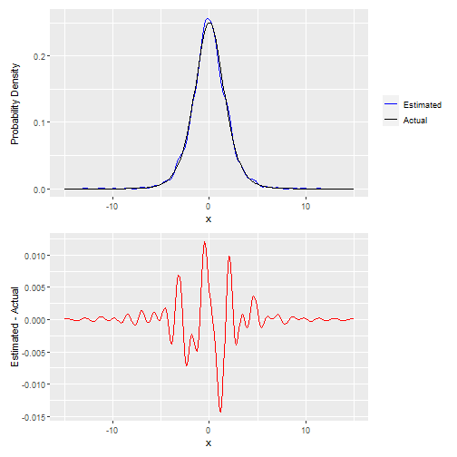

```r
observations <- rlogis(n=5000)
hermite_est <- hermite_estimator(observations = observations)
x <- seq(-15,15,0.1)
pdf_est <- dens(hermite_est,x)
cdf_est <- cum_prob(hermite_est,x)
p <- seq(0.05,0.95,0.05)
quantile_est <- quant(hermite_est,p)
actual_pdf <- dlogis(x)
actual_cdf <- plogis(x)
df_pdf_cdf <- data.frame(x,pdf_est,cdf_est,actual_pdf,actual_cdf)
actual_quantiles <- qlogis(p)
df_quant <- data.frame(p,quantile_est,actual_quantiles)

pdf_comp_plot <- ggplot(df_pdf_cdf,aes(x=x)) +
  geom_line(aes(y=pdf_est, colour="Estimated")) +
  geom_line(aes(y=actual_pdf, colour="Actual")) +
  scale_colour_manual("",
                      breaks = c("Estimated", "Actual"),
                      values = c("blue", "black")) + ylab("Probability Density")

pdf_comp_plot / (ggplot(df_pdf_cdf,aes(x=x,y=pdf_est-actual_pdf)) +
                   geom_line(color="red")+ ylab("Estimated - Actual"))
```

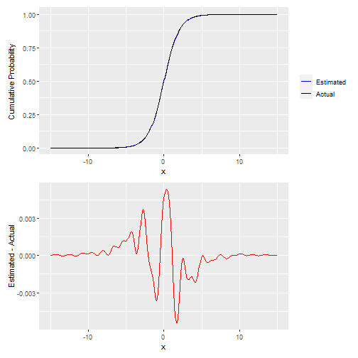

```r
cdf_comp_plot <- ggplot(df_pdf_cdf,aes(x=x)) +
  geom_line(aes(y=cdf_est, colour="Estimated")) +
  geom_line(aes(y=actual_cdf, colour="Actual")) +
  scale_colour_manual("",
                      breaks = c("Estimated", "Actual"),
                      values = c("blue", "black")) +
  ylab("Cumulative Probability")
cdf_comp_plot / (ggplot(df_pdf_cdf,aes(x=x,y=cdf_est-actual_cdf)) +
                   geom_line(color="red")+ ylab("Estimated - Actual"))
```

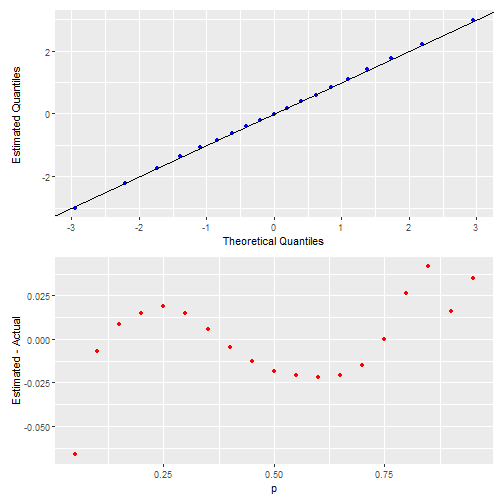

```r
quantile_comp_plot <-ggplot(df_quant,aes(x=actual_quantiles)) +
  geom_point(aes(y=quantile_est), color="blue") +
  geom_abline(slope=1,intercept = 0) +xlab("Theoretical Quantiles") +
  ylab("Estimated Quantiles")
quantile_comp_plot / (ggplot(df_quant,aes(x=p,y=quantile_est-
            actual_quantiles)) + geom_point(color="red") +
              ylab("Estimated - Actual"))
```

Reproduce bivariate PDF, CDF figures, namely **Figure 4** and **Figure 5** in the text respectively.

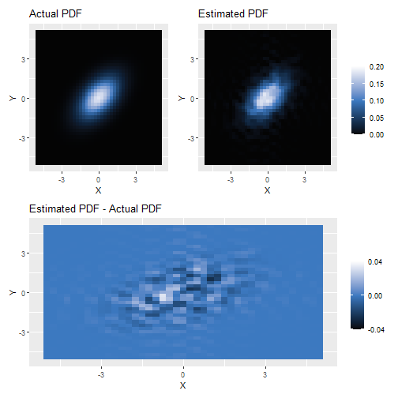

```r
sig_x <- 1
sig_y <- 1
num_obs <- 5000
rho <- 0.5
observations_mat <- mvtnorm::rmvnorm(n=num_obs,mean=rep(0,2),
                                     sigma = matrix(c(sig_x^2,rho*sig_x*sig_y,
                                                    rho*sig_x*sig_y,sig_y^2),
                                                  nrow=2,ncol=2, byrow = TRUE))
hermite_est <- hermite_estimator(est_type = "bivariate",
                                 observations = observations_mat)
vals <- seq(-5,5,by=0.25)
x_grid <- as.matrix(expand.grid(X=vals, Y=vals))
pdf_est <- dens(hermite_est,x_grid, clipped = TRUE)
cdf_est <- cum_prob(hermite_est,x_grid,clipped = TRUE)
spear_est <- spearmans(hermite_est)
kendall_est <- kendall(hermite_est)
actual_pdf <-mvtnorm::dmvnorm(x_grid,mean=rep(0,2),
                              sigma = matrix(c(sig_x^2,rho*sig_x*sig_y,
                                               rho*sig_x*sig_y,sig_y^2),
                                             nrow=2,ncol=2, byrow = TRUE))
actual_cdf <- rep(NA,nrow(x_grid))
for (row_idx in seq_len(nrow(x_grid))) {
  actual_cdf[row_idx] <-  mvtnorm::pmvnorm(lower = c(-Inf,-Inf),
                                           upper=as.numeric(x_grid[row_idx,]),
                                           mean=rep(0,2), sigma =
                                          matrix(c(sig_x^2, rho*sig_x*sig_y,
                                           rho*sig_x*sig_y,sig_y^2), nrow=2,
                                           ncol=2, byrow = TRUE))
}
actual_spearmans <- cor(observations_mat,method = "spearman")[1,2]
actual_kendall <- cor(observations_mat,method = "kendall")[1,2]
df_pdf_cdf <- data.frame(x_grid,pdf_est,cdf_est,actual_pdf,actual_cdf)

p1 <- ggplot(df_pdf_cdf) + geom_tile(aes(X, Y, fill= actual_pdf)) +
  scale_fill_continuous_sequential(palette="Oslo",
                                   breaks=seq(0,.2,by=.05),
                                   limits=c(0,.2))

p2 <- ggplot(df_pdf_cdf) + geom_tile(aes(X, Y, fill= pdf_est)) +
  scale_fill_continuous_sequential(palette="Oslo",
                                   breaks=seq(0,.2,by=.05),
                                   limits=c(0,.2))

pdf_diff <- ggplot(df_pdf_cdf) + geom_tile(aes(X, Y, fill
                                               = pdf_est - actual_pdf)) +
  scale_fill_continuous_sequential(palette="Oslo",
                                   breaks=seq(-.04,.04,by=.04),
                                   limits=c(-.04,.04))

(p1+ ggtitle("Actual PDF")+ theme(legend.title = element_blank()) + p2 +
  ggtitle("Estimated PDF") +theme(legend.title = element_blank()) +
  plot_layout(guides = 'collect')) / (pdf_diff +
  ggtitle("Estimated PDF - Actual PDF") +
    theme(legend.title = element_blank()))
```

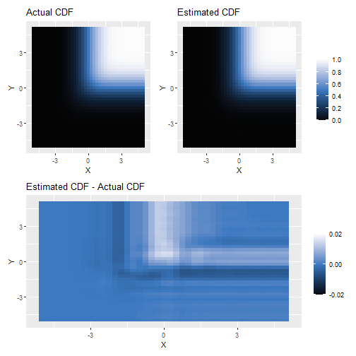

```r
p1 <- ggplot(df_pdf_cdf) + geom_tile(aes(X, Y, fill= actual_cdf)) +
  scale_fill_continuous_sequential(palette="Oslo",
                       breaks=seq(0,1,by=.2),
                       limits=c(0,1))

p2 <- ggplot(df_pdf_cdf) + geom_tile(aes(X, Y, fill= cdf_est)) +
  scale_fill_continuous_sequential(palette="Oslo",
                                   breaks=seq(0,1,by=.2),
                                   limits=c(0,1))

cdf_diff <- ggplot(df_pdf_cdf) + geom_tile(aes(X, Y, fill
                                               = cdf_est - actual_cdf)) +
  scale_fill_continuous_sequential(palette="Oslo",
                                   breaks=seq(-.02,.02,by=.02),
                                   limits=c(-.02,.02))

(p1+ ggtitle("Actual CDF") + theme(legend.title = element_blank()) + p2 +
  ggtitle("Estimated CDF") + theme(legend.title = element_blank())+
  plot_layout(guides = 'collect')) / (cdf_diff +
                                        ggtitle("Estimated CDF - Actual CDF") +
                                        theme(legend.title = element_blank()))
```

Reproduce actual and estimated Spearman and Kendall correlation coefficient results for **Table 3** in the text.

Actual Spearmans

```r
print(round(actual_spearmans,3))
```

```
## [1] 0.479
```

Estimated Spearmans

```r
print(round(spear_est,3))
```

```
## [1] 0.475
```

Actual Kendall

```r
print(round(actual_kendall,3))
```

```
## [1] 0.331
```

Estimated Kendall

```r
print(round(kendall_est,3))
```

```
## [1] 0.33
```

Reproduce quantile estimate results on EUR/USD and GBP/USD as presented in **Table 4** in the text.

```r
spread_data <-
  arrow::read_parquet("./eurusd_gbpusd_spread_2021_10.parquet")
percs <- c(0.01,0.1,0.25,0.5,0.75,0.9,0.99)
hermite_ests <- by(spread_data, list(spread_data$hr,spread_data$currency_pair),
        function(x){hermite_estimator(observations = log(x$spread_bps+1e-8))})
quantiles_ests <- t(sapply(hermite_ests,FUN=function(x){exp(quant(x,percs))}))
eur_usd_merged <- merge_hermite(as.list(hermite_ests)[1:24])
gbp_usd_merged <- merge_hermite(as.list(hermite_ests)[25:48])
gbp_all_hours <- exp(quant(gbp_usd_merged,percs))
eur_all_hours <- exp(quant(eur_usd_merged,percs))
dim(gbp_all_hours) <- c(1,length(percs))
dim(eur_all_hours) <- c(1,length(percs))
result <- data.frame(currency_pair = rep(attr(hermite_ests,"dimnames")[[2]],
                each=24), hour_utc = rep(attr(hermite_ests,"dimnames")[[1]],2),
                quantiles_ests)
result <- rbind(result,
        data.frame(currency_pair = "EUR/USD", hour_utc = "All", eur_all_hours))
result <- rbind(result,
        data.frame(currency_pair = "GBP/USD", hour_utc = "All", gbp_all_hours))
colnames(result) <- c("currency_pair", "hour_utc", paste0("p_",percs*100,"%"))
print(result,digits=1)
```

```
##    currency_pair hour_utc p_1% p_10% p_25% p_50% p_75% p_90% p_99%
## 1        EUR/USD        0  0.2   0.3   0.3   0.4   0.4   0.5   0.7
## 2        EUR/USD        1  0.2   0.3   0.3   0.4   0.4   0.4   0.5
## 3        EUR/USD        2  0.2   0.3   0.3   0.4   0.4   0.5   0.6
## 4        EUR/USD        3  0.2   0.3   0.3   0.4   0.4   0.5   0.6
## 5        EUR/USD        4  0.2   0.3   0.3   0.4   0.4   0.5   0.6
## 6        EUR/USD        5  0.2   0.3   0.3   0.4   0.4   0.5   0.6
## 7        EUR/USD        6  0.2   0.3   0.3   0.4   0.4   0.4   0.5
## 8        EUR/USD        7  0.2   0.3   0.3   0.4   0.4   0.5   0.5
## 9        EUR/USD        8  0.2   0.3   0.3   0.4   0.4   0.4   0.5
## 10       EUR/USD        9  0.2   0.3   0.3   0.4   0.4   0.4   0.5
## 11       EUR/USD       10  0.1   0.2   0.3   0.4   0.4   0.5   0.6
## 12       EUR/USD       11  0.2   0.3   0.3   0.4   0.4   0.5   0.6
## 13       EUR/USD       12  0.2   0.3   0.3   0.3   0.4   0.4   0.5
## 14       EUR/USD       13  0.2   0.3   0.3   0.4   0.4   0.4   0.5
```

[output cut: 36 more lines]

Reproduce sequential quantile estimate results on EUR/USD and GBP/USD as presented in **Figure 6** in the text along with sequential Spearman and Kendall correlation estimates presented in **Figure 7** in the text.

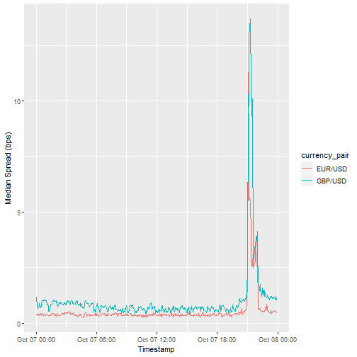

```r
eur_data <- spread_data[which(spread_data$currency_pair == "EUR/USD" &
            spread_data$time_stamp >= as.POSIXct(as.Date("2021-10-07")) &
              spread_data$time_stamp < as.POSIXct(as.Date("2021-10-08"))),]
gbp_data <-spread_data[which(spread_data$currency_pair == "GBP/USD" &
            spread_data$time_stamp >= as.POSIXct(as.Date("2021-10-07")) &
              spread_data$time_stamp < as.POSIXct(as.Date("2021-10-08"))),]
eur_data <- eur_data[order(eur_data$time_stamp),]
gbp_data <- gbp_data[order(gbp_data$time_stamp),]
h_est_eur <- hermite_estimator(exp_weight_lambda = 0.05)
h_est_gbp <- hermite_estimator(exp_weight_lambda = 0.05)
h_est_bivariate <- hermite_estimator(est_type = "bivariate",
                                     exp_weight_lambda = 0.05)
output_eur <- rep(NA,nrow(eur_data))
output_gbp <- rep(NA,nrow(gbp_data))
output_spearman<- rep(NA,nrow(gbp_data))
output_kendall<- rep(NA,nrow(gbp_data))
for (idx in seq_len(nrow(eur_data))) {
  current_obs_eur <- eur_data[idx,]$spread_bps
  current_obs_gbp <- gbp_data[idx,]$spread_bps
  h_est_eur <- update_sequential(h_est_eur,log(current_obs_eur+1e-8))
  h_est_gbp <- update_sequential(h_est_gbp,log(current_obs_gbp +1e-8))
  h_est_bivariate <- update_sequential(h_est_bivariate,
                        c(log(current_obs_eur+1e-8),log(current_obs_gbp+1e-8)))
  output_eur[idx] <- exp(quant(h_est_eur,p=0.5))
  output_gbp[idx] <- exp(quant(h_est_gbp,p=0.5))
  output_spearman[idx] <- spearmans(h_est_bivariate)
  output_kendall[idx] <- kendall(h_est_bivariate)
}
output_res_df_eur <- data.frame(time_stamp = eur_data$time_stamp,
                          median_spread = output_eur, currency_pair="EUR/USD")
output_res_df_gbp <- data.frame(time_stamp = gbp_data$time_stamp,
                          median_spread = output_gbp, currency_pair="GBP/USD")
output_res_df <- rbind(output_res_df_eur,output_res_df_gbp)
output_spearman_df <- data.frame(time_stamp = eur_data$time_stamp,
                                correlation=output_spearman, type="spearman" )
output_spearman_df <- output_spearman_df[seq(1,nrow(output_spearman_df),by=10),]
output_kendall_df <- data.frame(time_stamp = eur_data$time_stamp,
                                correlation=output_kendall , type="kendall" )
output_kendall_df <- output_kendall_df[seq(1,nrow(output_kendall_df),by=10),]
output_correl_df <- rbind(output_spearman_df, output_kendall_df)
output_correl_df <- output_correl_df[order(output_correl_df$time_stamp),]
output_res_df_plot <- output_res_df[seq(1,nrow(output_res_df),by=10),]
ggplot(output_res_df_plot,mapping=aes(x=time_stamp ,y=median_spread,color =
        currency_pair)) + geom_line() + xlab("Timestamp") +
         ylab("Median Spread (bps)")
```

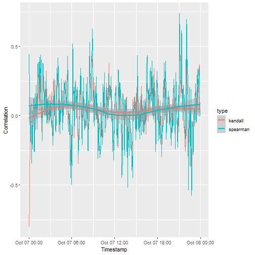

```r
ggplot(output_correl_df,mapping=aes(x=time_stamp, y=correlation,color=type)) +
  geom_line() +geom_smooth() + xlab("Timestamp") + ylab("Correlation")
```

Benchmark hermiter vs tdigest (parallel computation enabled), updating with 1e6 observations. Reproduces **Figure 8** in the text.

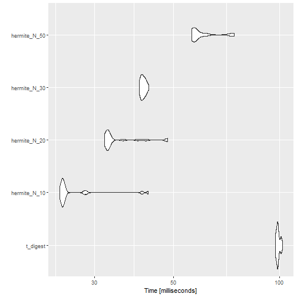

```r
obs <- rnorm(1e6)
bench_res <- microbenchmark::microbenchmark(
  t_digest = tdigest(obs),
  hermite_N_10 = hermite_estimator(N = 10, observations = obs),
  hermite_N_20 = hermite_estimator(N = 20, observations = obs),
  hermite_N_30 = hermite_estimator(N = 30, observations = obs),
  hermite_N_50 = hermite_estimator(N = 50, observations = obs),
  times = 20
)
autoplot(bench_res, log = TRUE)
```

```r
print(bench_res)
```

```
## Unit: milliseconds
##          expr     min       lq     mean   median       uq      max neval
##      t_digest 97.3098 98.14090 98.94098 98.70065 99.58645 101.8031    20
##  hermite_N_10 23.8611 24.22610 26.47650 24.42310 24.81625  42.5259    20
##  hermite_N_20 31.9809 32.46780 35.16618 32.67305 34.62435  48.2838    20
##  hermite_N_30 40.0571 40.60320 41.12018 40.98390 41.57010  42.6173    20
##  hermite_N_50 56.4826 57.23035 60.30319 57.39500 61.20965  74.3275    20
```

Benchmark hermiter vs tdigest (parallel computation disabled), updating with 1e6 observations. Reproduces **Figure 9** in the text.

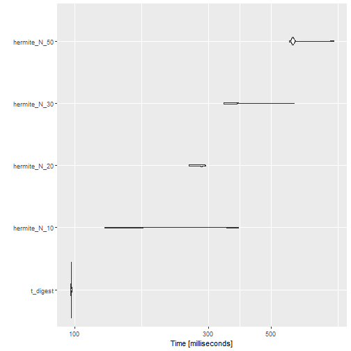

```r
options(hermiter.parallel = FALSE)
bench_res <- microbenchmark::microbenchmark(
  t_digest = tdigest(obs),
  hermite_N_10 = hermite_estimator(N = 10, observations = obs),
  hermite_N_20 = hermite_estimator(N = 20, observations = obs),
  hermite_N_30 = hermite_estimator(N = 30, observations = obs),
  hermite_N_50 = hermite_estimator(N = 50, observations = obs),
  times = 20
)
autoplot(bench_res, log = TRUE)
```

```r
print(bench_res)
```

```
## Unit: milliseconds
##          expr      min        lq      mean   median       uq      max neval
##      t_digest  96.4097  96.94005  97.07654  97.1558  97.2563  97.8746    20
##  hermite_N_10 127.5902 129.94110 162.93353 134.5115 153.5274 381.7957    20
##  hermite_N_20 254.6851 263.29775 273.58323 276.9704 283.4670 292.7922    20
##  hermite_N_30 339.0049 350.70885 382.53319 363.1500 373.3352 604.3701    20
##  hermite_N_50 581.8368 594.12540 620.07919 597.4981 602.7125 837.2012    20
```

```r
options(hermiter.parallel = TRUE)
```

Benchmark hermiter vs tdigest, quantile estimation. Reproduces **Figure 10** in the text.

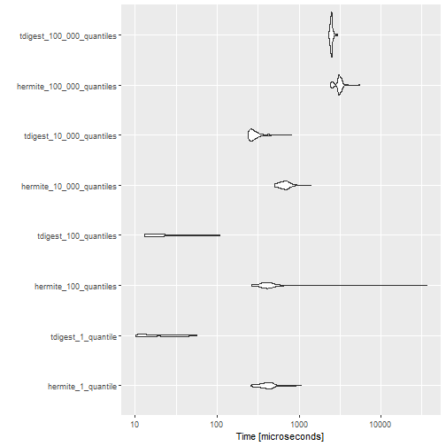

```r
obs <- rnorm(1e6)
td <- tdigest(obs)
h_est <-
  hermite_estimator(observations = obs)
p_1 <- 0.5
p_100 <- seq(0.01, 1, 0.01)
p_10000 <- seq(0.0001, 1, 0.0001)
p_100000 <- seq(0.00001, 1, 0.00001)
bench_res <- microbenchmark::microbenchmark(
  hermite_1_quantile =  quant(h_est, p = p_1),
  tdigest_1_quantile = quantile(td, probs = p_1),
  hermite_100_quantiles = quant(h_est, p = p_100),
  tdigest_100_quantiles = quantile(td, probs = p_100),
  hermite_10_000_quantiles = quant(h_est, p = p_10000),
  tdigest_10_000_quantiles = quantile(td, probs = p_10000),
  hermite_100_000_quantiles = quant(h_est, p = p_100000),
  tdigest_100_000_quantiles = quantile(td, probs = p_100000),
  times = 1e2
)
autoplot(bench_res,
         log = T,
         xlab = "Algorithm",
         ylab = "Time (millis)")
```

```r
print(bench_res)
```

```
## Unit: microseconds
##                       expr    min      lq     mean  median      uq     max neval
##         hermite_1_quantile  258.2  348.05  421.941  406.80  454.45  1064.2   100
##         tdigest_1_quantile   10.2   12.55   23.833   20.65   32.85    56.4   100
##      hermite_100_quantiles  265.9  353.25  786.992  408.50  464.40 35910.4   100
##      tdigest_100_quantiles   13.1   15.95   28.017   21.55   37.55   109.1   100
##   hermite_10_000_quantiles  502.5  595.55  674.612  672.15  728.15  1397.5   100
##   tdigest_10_000_quantiles  240.8  257.75  291.264  273.40  300.60   817.8   100
##  hermite_100_000_quantiles 2421.3 2965.50 3056.162 3064.70 3241.50  5493.4   100
##  tdigest_100_000_quantiles 2325.9 2428.70 2484.415 2484.75 2521.80  2928.9   100
```

Univariate simulation study comparing hermiter and tdigest for quantile estimation.

```r
calculate_miae_per_distro <- function(full_miae = FALSE) {
  distros_index <- c(1:5, 7:8, 11, 13:17, 21:28)
  numruns <- total_number_of_runs
  num_obs_vec <- c(1e4, 1e5, 1e6, 1e7)
  if (full_miae == TRUE) {
    p <- randtoolbox::sobol(1000)
    norm_factor <- 1
  } else {
    p <- randtoolbox::sobol(1000) * 0.98 + 0.01
    norm_factor <- 0.98
  }
  distr_name_all <- c()
  num_obs_all <- c()
  mae_hermite_quant <- c()
  mae_t_digest_quant <- c()
  count <- 0
  for (num_obs in num_obs_vec) {
    for (current_distro_idx in seq_along(distros_index)) {
      dnum <- distros_index[current_distro_idx]
      distr_name <- benchden::berdev(dnum)$name
      r_func <-
        function(core_obs) {
          benchden::rberdev(n = core_obs, dnum = dnum)
        }
      q_func <-
        function(p_est) {
          benchden::qberdev(p_est, dnum = dnum)
        }
      p_func <- function(x) {
        benchden::pberdev(x, dnum = dnum)
      }
      res_hermite_quant <- rep(0, numruns)
      res_t_digest_quant <- rep(0, numruns)
      for (run in c(1:numruns)) {
        obs <- r_func(num_obs)
        h_est <- hermite_estimator(observations = obs )
        td <- tdigest(obs)
        q_est_hermite <- h_est %>% quant(p)
        q_est_t_digest <- quantile(td, probs = p)
        true_quant <- q_func(p)
        res_hermite_quant[run] <- norm_factor *
          mean(abs(q_est_hermite - true_quant))
        res_t_digest_quant[run] <- norm_factor *
          mean(abs(q_est_t_digest - true_quant))
      }
      mae_herm_quant <- mean(res_hermite_quant)
      mae_t_dig_quant <- mean(res_t_digest_quant)
      count <- count + 1
      distr_name_all[count] <- distr_name
      num_obs_all[count] <- num_obs
      mae_hermite_quant[count] <- mae_herm_quant
      mae_t_digest_quant[count] <- mae_t_dig_quant
    }
  }
  result <- data.frame(
    distribution_name = distr_name_all,
    num_obs =
      num_obs_all,
    mae_hermite_quant,
    mae_t_digest_quant
  )
  result <- result %>% mutate(hermite_better_quant =
                                ifelse(mae_hermite_quant < mae_t_digest_quant,
                                       1, 0))
  return(result)
}
```

```r
calculate_miae <- function(miae_per_distro) {
  univariate_quantile_results <- miae_per_distro %>%
    group_by(num_obs) %>%
    summarise(
      num_herm_better = sum(hermite_better_quant),
      total_distros = n(),
      perc_herm_better =
        sum(hermite_better_quant) / n()
    )
  return(univariate_quantile_results)
}

univar_quant_results_partial_per_distro <-
  calculate_miae_per_distro(full_miae = FALSE)
univar_quant_results_full_per_distro <-
  calculate_miae_per_distro(full_miae = TRUE)

univar_quant_results_partial <-
  calculate_miae(univar_quant_results_partial_per_distro)
univar_quant_results_full <-
  calculate_miae(univar_quant_results_full_per_distro)
```

Reproduces **Table 5** in the text:

```r
print(univar_quant_results_full)
```

```
## # A tibble: 4 × 4
##    num_obs num_herm_better total_distros perc_herm_better
##      <dbl>           <dbl>         <int>            <dbl>
## 1    10000              12            21            0.571
## 2   100000              16            21            0.762
## 3  1000000              18            21            0.857
## 4 10000000              18            21            0.857
```

Reproduces **Table 6** in the text:

```r
print(univar_quant_results_partial)
```

```
## # A tibble: 4 × 4
##    num_obs num_herm_better total_distros perc_herm_better
##      <dbl>           <dbl>         <int>            <dbl>
## 1    10000              15            21            0.714
## 2   100000              18            21            0.857
## 3  1000000              18            21            0.857
## 4 10000000              19            21            0.905
```

R implementation of count matrix algorithm of Xiao, Wei. “Novel online algorithms for nonparametric correlations with application to analyze sensor data.” 2019 IEEE International Conference on Big Data (Big Data). IEEE, as an S3 class. The implementation below follows https://github.com/wxiao0421/onlineNPCORR/ reasonably closely in parts.

```r
count_matrix_calculator <-
  function(cut_points_inpt, normalize = FALSE) {
    this <- list(
      cut_points = cut_points_inpt,
      count_matrix = matrix(
        rep(0, cut_points_inpt ^ 2),
        nrow = cut_points_inpt,
        ncol = cut_points_inpt,
        byrow = TRUE
      ),
      n_row = rep(0, cut_points_inpt),
      n_col = rep(0, cut_points_inpt),
      x_breaks = qnorm(p = seq(0, 1, length.out =
                                 (
                                   cut_points_inpt + 1
                                 )))[2:(cut_points_inpt)],
      y_breaks = qnorm(p = seq(0, 1, length.out =
                                 (
                                   cut_points_inpt + 1
                                 )))[2:(cut_points_inpt)],
      num_obs = 0,
      normalize_obs = normalize,
      running_mean_x = 0,
      running_mean_y = 0,
      running_variation_x = 0,
      running_variation_y = 0
    )
    class(this) <- append(class(this), "count_matrix_calculator")
    return(this)
  }

get_idx <- function(x, breaks) {
  if (breaks[length(breaks)] < x) {
    return(length(breaks) + 1)
  }
  return(which(breaks >= x)[1])
}

update_matrix <- function(this, x) {
  UseMethod("update_matrix", this)
}

update_matrix.count_matrix_calculator <- function(this, x) {
  this$num_obs <- this$num_obs + 1
  if (this$normalize_obs == TRUE) {
    prev_mean <- c(this$running_mean_x, this$running_mean_y)
    upd_mean <- (prev_mean * (this$num_obs - 1) + x) / this$num_obs
    this$running_mean_x  <- upd_mean[1]
    this$running_mean_y  <- upd_mean[2]
    if (this$num_obs < 2) {
      return(this)
    }
    upd_var <- c(this$running_variation_x,
                 this$running_variation_y) + (x - prev_mean) *
      (x - upd_mean)
    this$running_variation_x <- upd_var[1]
    this$running_variation_y <- upd_var[2]
    x <- (x - upd_mean) / sqrt(upd_var / (this$num_obs))
  }
  idx_row <- get_idx(x[1], this$x_breaks)
  idx_col <- get_idx(x[2], this$y_breaks)
  this$count_matrix[idx_row, idx_col] <-
    this$count_matrix[idx_row, idx_col] + 1
  this$n_row[idx_row] <- this$n_row[idx_row] + 1
  this$n_col[idx_col] <- this$n_col[idx_col] + 1
  return(this)
}

get_spearmans <- function(this) {
  UseMethod("get_spearmans", this)
}

get_spearmans.count_matrix_calculator <- function(this) {
  len_x_breaks <- length(this$x_breaks)
  len_y_breaks <- length(this$y_breaks)
  r_row <- rep(0, len_x_breaks + 1)
  r <- 0
  for (k in c(1:(len_x_breaks + 1))) {
    if (this$n_row[k] == 0) {
      r_row[k] <- r
    } else {
      r_row[k] <- ((r + 1) + (r + this$n_row[k])) / 2
      r <- r + this$n_row[k]
    }
  }
  r_col <- rep(0, len_y_breaks + 1)
  r <- 0
  for (k in c(1:(len_y_breaks + 1))) {
    if (this$n_col[k] == 0) {
      r_col[k] <- r
    } else {
      r_col[k] <- ((r + 1) + (r + this$n_col[k])) / 2
      r <- r + this$n_col[k]
    }
  }
  r_row <- r_row - (this$num_obs + 1) / 2
  r_col <- r_col - (this$num_obs + 1) / 2
  r_row <- r_row / sqrt(sum(this$n_row * r_row ^ 2))
  r_col <- r_col / sqrt(sum(this$n_col * r_col ^ 2))
  corr <- t(r_row) %*% this$count_matrix %*% r_col
  return(corr)
}

get_kendall <- function(this) {
  UseMethod("get_kendall", this)
}

get_kendall.count_matrix_calculator <- function(this) {
  len_n_row <- length(this$n_row)
  len_n_col <- length(this$n_col)
  count_mat_sum <-
    matrix(rep(0, len_n_row * len_n_col), len_n_row, len_n_col, byrow = TRUE)
  for (i in 2:len_n_row) {
    count_mat_sum[i, 2:len_n_col] <-
      cumsum(this$count_matrix[(i - 1), 1:(len_n_col - 1)])
  }
  for (i in 2:len_n_row) {
    count_mat_sum[i, ] <- count_mat_sum[i, ] + count_mat_sum[(i - 1), ]
  }
  concord_pairs <- sum(this$count_matrix * count_mat_sum)
  ties_in_x <- 0
  for (i in 1:len_n_row) {
    ties_in_x <- ties_in_x + (this$n_row[i] ^ 2 -
                                sum(this$count_matrix[i, ] ^ 2)) / 2
  }
  ties_in_y <- 0
  for (j in 1:len_n_col) {
    ties_in_y <- ties_in_y + (this$n_col[j] ^ 2 -
                                sum(this$count_matrix[, j] ^ 2)) / 2
  }
  ties_in_x_and_y <- sum(this$count_matrix * (this$count_matrix - 1)) / 2
  discord_pairs <- this$num_obs * (this$num_obs - 1) / 2 - concord_pairs -
    ties_in_x - ties_in_y - ties_in_x_and_y
  corr <- (concord_pairs - discord_pairs) /
    sqrt((concord_pairs + discord_pairs + ties_in_x) *
           (concord_pairs + discord_pairs + ties_in_y))
  return(corr)
}
```

Bivariate simulation study comparing hermiter and count matrix algorithms for estimation of Spearman’s Rho and Kendall Tau coefficients.

```r
rho_inpt <- c(-0.75, -0.5, -0.25, 0.25, 0.5, 0.75)
num_obs_inpt <- c(1e4, 5e4, 1e5)
runs <- total_number_of_runs
mae_matrix_kendall <- c()
mae_hermite_kendall <- c()
mae_matrix_spear <- c()
mae_hermite_spear <- c()
rho_vec <- c()
num_obs_vec <- c()
sig_x <- 1
sig_y <- 1
for (num_obs in num_obs_inpt) {
  for (rho in rho_inpt) {
    for (j in 1:runs) {
      obs_mat <- mvtnorm::rmvnorm(
        n = num_obs,
        mean = rep(0, 2),
        sigma = matrix(
          c(sig_x ^ 2, rho * sig_x * sig_y,
            rho * sig_x * sig_y, sig_y ^ 2),
          nrow = 2,
          ncol = 2,
          byrow = T
        )
      )
      matrix_est_c30 <-
        count_matrix_calculator(cut_points_inpt = 30,
                                normalize = F)
      matrix_est_c100 <-
        count_matrix_calculator(cut_points_inpt = 100,
                                normalize = F)
      hermite_est <-
        hermite_estimator(est_type = "bivariate", standardize = F)
      for (i in seq_len(nrow(obs_mat))) {
        matrix_est_c100 <- matrix_est_c100 %>% update_matrix(obs_mat[i, ])
        matrix_est_c30 <-
          matrix_est_c30 %>% update_matrix(obs_mat[i, ])
        hermite_est <-
          hermite_est %>% update_sequential(obs_mat[i, ])
      }
      kendall_est_matrix <-
        matrix_est_c100 %>% get_kendall()
      kendall_est_hermite <- hermite_est %>% kendall()
      spear_est_matrix <-
        matrix_est_c30 %>% get_spearmans()
      spear_est_hermite <- hermite_est %>% spearmans()
      kendall_true <- 2 / pi * asin(rho)
      spear_true <- cor(obs_mat, method = "spearman")[1, 2]
      mae_matrix_kendall <- append(mae_matrix_kendall,
                                   abs(kendall_est_matrix - kendall_true))
      mae_hermite_kendall <- append(mae_hermite_kendall,
                                    abs(kendall_est_hermite - kendall_true))
      mae_matrix_spear <- append(mae_matrix_spear,
                                 abs(spear_est_matrix - spear_true))
      mae_hermite_spear <- append(mae_hermite_spear,
                                  abs(spear_est_hermite - spear_true))
      num_obs_vec <- append(num_obs_vec, num_obs)
      rho_vec <- append(rho_vec, rho)
    }
  }
}
result <-
  data.frame(
    num_obs_vec,
    rho_vec,
    mae_matrix_kendall,
    mae_hermite_kendall,
    mae_matrix_spear,
    mae_hermite_spear
  )
summary_by_rho_and_num_obs <-
  result %>%
  group_by(num_obs_vec, rho_vec) %>%
  summarise(
    mae_matrix_kendall = mean(mae_matrix_kendall),
    mae_hermite_kendall =
      mean(mae_hermite_kendall),
    mae_matrix_spear = mean(mae_matrix_spear),
    mae_hermite_spear = mean(mae_hermite_spear)
  )
summary_num_obs_kendall <- summary_by_rho_and_num_obs %>%
  group_by(num_obs_vec) %>%
  summarise(
    mae_matrix_kendall_avg =
      mean(mae_matrix_kendall) * 100,
    mae_hermite_kendall_avg =
      mean(mae_hermite_kendall) * 100,
    sd_matrix_kendall =
      sd(mae_matrix_kendall) * 100,
    sd_hermite_kendall = sd(mae_hermite_kendall) * 100
  )
summary_num_obs_spear  <- summary_by_rho_and_num_obs %>%
  group_by(num_obs_vec) %>%
  summarise(
    mae_matrix_spear_avg =
      mean(mae_matrix_spear) * 100,
    mae_hermite_spear_avg = mean(mae_hermite_spear) * 100,
    sd_matrix_spear = sd(mae_matrix_spear) * 100,
    sd_hermite_spear =
      sd(mae_hermite_spear) * 100
  )
```

Reproduces **Table 7** in the text.

```r
print(summary_num_obs_spear)
```

```
## # A tibble: 3 × 5
##   num_obs_vec mae_matrix_spear_avg mae_hermite_spear_avg sd_matrix_spear sd_hermite_spear
##         <dbl>                <dbl>                 <dbl>           <dbl>            <dbl>
## 1       10000               0.0947                0.146           0.0288          0.0502
## 2       50000               0.0990                0.0577          0.0295          0.00937
## 3      100000               0.103                 0.0550          0.0271          0.00847
```

Reproduces **Table 8** in the text.

```r
print(summary_num_obs_kendall)
```

```
## # A tibble: 3 × 5
##   num_obs_vec mae_matrix_kendall_avg mae_hermite_kendall_avg sd_matrix_kendall sd_hermite_kendall
##         <dbl>                  <dbl>                   <dbl>             <dbl>              <dbl>
## 1       10000                  0.566                   0.653             0.140             0.163
## 2       50000                  0.377                   0.210             0.148             0.0486
## 3      100000                  0.377                   0.153             0.140             0.0565
```

Reproduces **Figure 11** in the text.

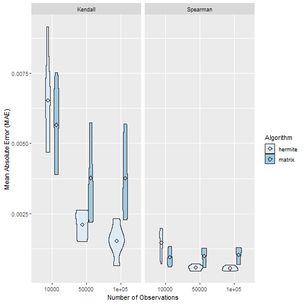

```r
pivoted_summary <- summary_by_rho_and_num_obs %>%
  tidyr::pivot_longer(cols=-c(num_obs_vec,rho_vec)) %>%
  tidyr::separate(col=name,sep = "_",into=
                    c("metric","method","correlation_type")) %>%
  mutate(correlation_type=ifelse(correlation_type ==
                                   "spear","Spearman","Kendall"))

ggplot(pivoted_summary,
            aes(x=as.factor(num_obs_vec),y=value,fill=method)) +
            geom_violin(position=position_dodge(.5)) +
            stat_summary(fun=mean, geom="point", shape=23, size=2,
                         position = position_dodge(.5))+
            scale_fill_brewer(palette="Blues") +
            facet_wrap(~correlation_type,nrow=1) +
            xlab("Number of Observations")+
            ylab("Mean Absolute Error (MAE)")+ labs(fill = "Algorithm")
```

Computational Details